# InVivoStat Repeated Measures Parametric Analysis

## Diagnostic plots

### Residuals vs. predicted plot

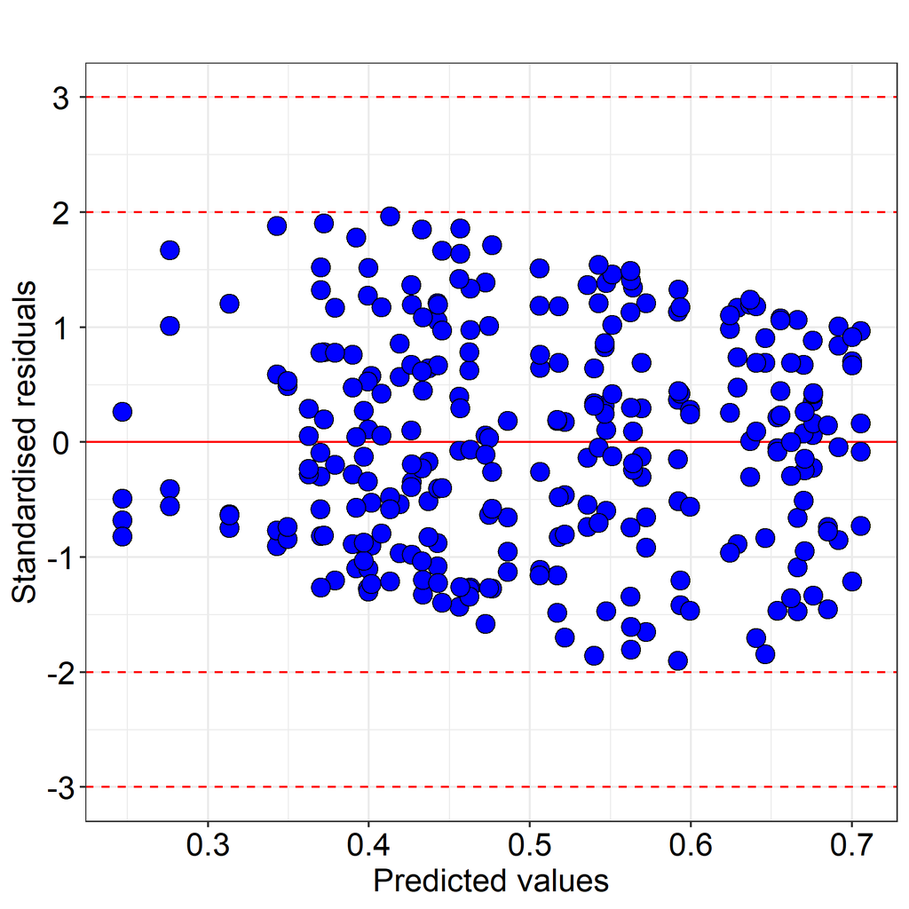

Tip: On this plot look to see if the spread of the points increases as the predicted values increase. If so the response may need transforming.

Tip: Any observation with a standardised residual less than -3 or greater than 3 (SD) should be investigated as a possible outlier.

Comment: The standardised residuals are obtained by subtracting the fitted values from the responses and dividing by the estimated within-group standard error.

### Normal probability plot

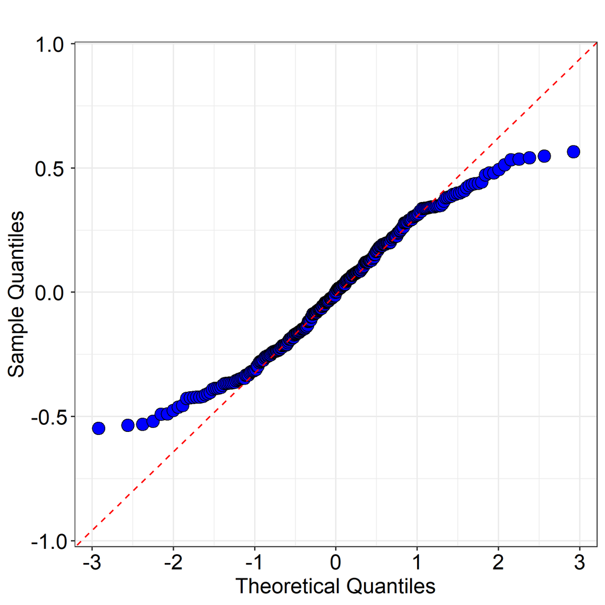

Tip: Check that the points lie along the dotted line. If not then the data may be non-normally distributed.

## Table of the least square (predicted) means with 95% confidence intervals

| Mean ID | Treat 1 | Treat 2 | Day 1 | Mean | Lower 95% CI | Upper 95% CI |
| --- | --- | --- | --- | --- | --- | --- |
| 1 | A | x | D1 | 0.521 | 0.320 | 0.721 |
| 2 | B | x | D1 | 0.404 | 0.204 | 0.605 |
| 3 | C | x | D1 | 0.691 | 0.490 | 0.891 |
| 4 | A | y | D1 | 0.652 | 0.451 | 0.852 |
| 5 | B | y | D1 | 0.532 | 0.331 | 0.732 |
| 6 | C | y | D1 | 0.685 | 0.485 | 0.886 |
| 7 | A | z | D1 | 0.491 | 0.291 | 0.692 |
| 8 | B | z | D1 | 0.614 | 0.414 | 0.815 |
| 9 | C | z | D1 | 0.670 | 0.470 | 0.871 |
| 10 | A | x | D2 | 0.441 | 0.241 | 0.642 |
| 11 | B | x | D2 | 0.448 | 0.248 | 0.649 |
| 12 | C | x | D2 | 0.533 | 0.332 | 0.733 |
| 13 | A | y | D2 | 0.577 | 0.377 | 0.778 |
| 14 | B | y | D2 | 0.458 | 0.257 | 0.658 |
| 15 | C | y | D2 | 0.448 | 0.247 | 0.648 |
| 16 | A | z | D2 | 0.655 | 0.455 | 0.856 |
| 17 | B | z | D2 | 0.262 | 0.061 | 0.462 |
| 18 | C | z | D2 | 0.411 | 0.211 | 0.612 |
| 19 | A | x | D3 | 0.385 | 0.184 | 0.585 |
| 20 | B | x | D3 | 0.428 | 0.227 | 0.628 |
| 21 | C | x | D3 | 0.639 | 0.439 | 0.839 |
| 22 | A | y | D3 | 0.554 | 0.354 | 0.755 |
| 23 | B | y | D3 | 0.422 | 0.222 | 0.623 |
| 24 | C | y | D3 | 0.385 | 0.184 | 0.585 |
| 25 | A | z | D3 | 0.364 | 0.164 | 0.565 |
| 26 | B | z | D3 | 0.471 | 0.271 | 0.672 |
| 27 | C | z | D3 | 0.377 | 0.177 | 0.578 |
| 28 | A | x | D4 | 0.677 | 0.476 | 0.877 |
| 29 | B | x | D4 | 0.661 | 0.460 | 0.861 |
| 30 | C | x | D4 | 0.328 | 0.128 | 0.529 |
| 31 | A | y | D4 | 0.557 | 0.357 | 0.758 |
| 32 | B | y | D4 | 0.579 | 0.378 | 0.779 |
| 33 | C | y | D4 | 0.577 | 0.377 | 0.778 |
| 34 | A | z | D4 | 0.460 | 0.259 | 0.660 |
| 35 | B | z | D4 | 0.387 | 0.186 | 0.587 |
| 36 | C | z | D4 | 0.536 | 0.336 | 0.737 |

## Plot of the least square (predicted) means with 95% confidence intervals

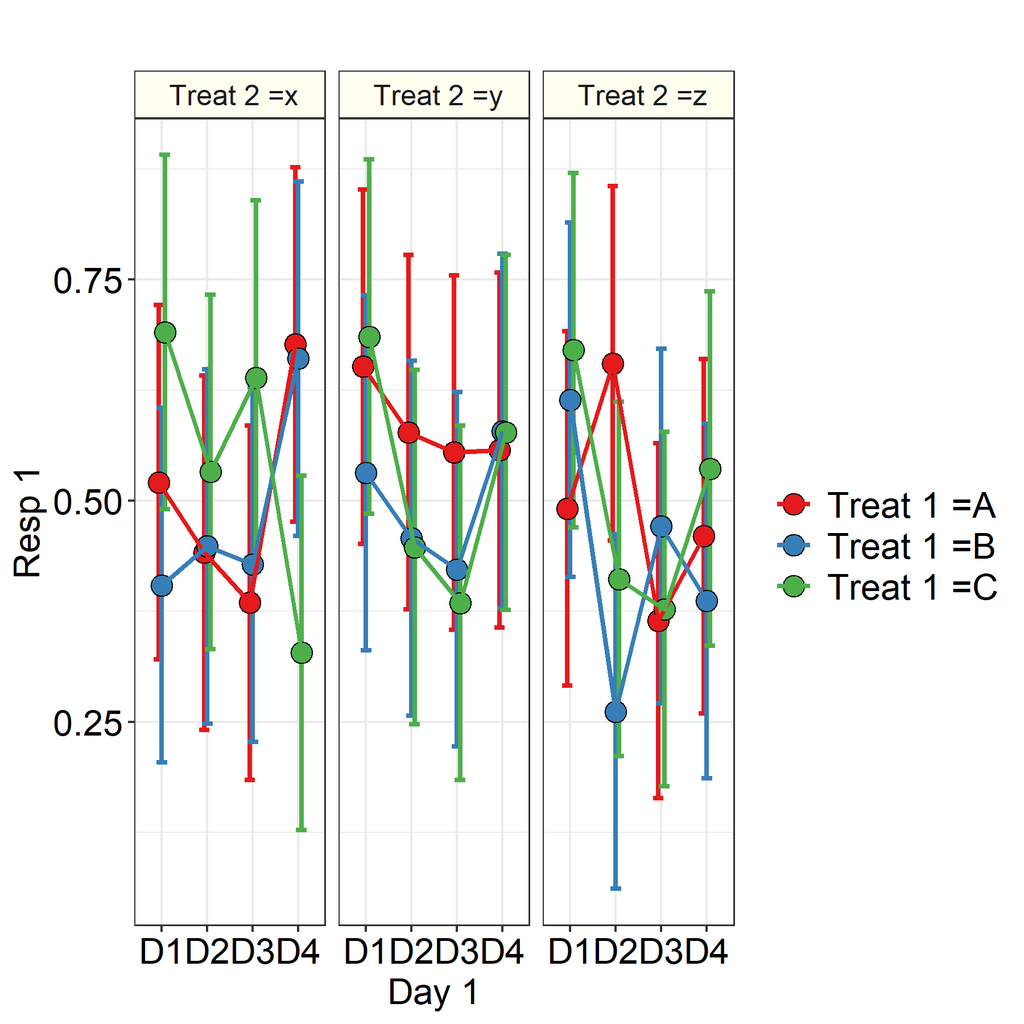

## Pairwise comparisons within the levels of the repeated factor, without adjustment for multiplicity

| Comparison | Difference | Lower 95% CI | Upper 95% CI | Std error | p-value |
| --- | --- | --- | --- | --- | --- |
| ( A , x , D1 ) - ( B , x , D1 ) | 0.116 | -0.167 | 0.400 | 0.14 | 0.4192 |
| ( A , x , D1 ) - ( C , x , D1 ) | -0.170 | -0.453 | 0.114 | 0.14 | 0.2397 |
| ( A , x , D1 ) - ( A , y , D1 ) | -0.131 | -0.414 | 0.153 | 0.14 | 0.3649 |
| ( A , x , D1 ) - ( B , y , D1 ) | -0.011 | -0.294 | 0.273 | 0.14 | 0.9413 |
| ( A , x , D1 ) - ( C , y , D1 ) | -0.165 | -0.448 | 0.119 | 0.14 | 0.2542 |
| ( A , x , D1 ) - ( A , z , D1 ) | 0.030 | -0.254 | 0.313 | 0.14 | 0.8367 |
| ( A , x , D1 ) - ( B , z , D1 ) | -0.093 | -0.377 | 0.190 | 0.14 | 0.5177 |
| ( A , x , D1 ) - ( C , z , D1 ) | -0.149 | -0.433 | 0.134 | 0.14 | 0.3005 |
| ( B , x , D1 ) - ( C , x , D1 ) | -0.286 | -0.570 | -0.003 | 0.14 | 0.0479 |
| ( B , x , D1 ) - ( A , y , D1 ) | -0.247 | -0.531 | 0.036 | 0.14 | 0.0872 |
| ( B , x , D1 ) - ( B , y , D1 ) | -0.127 | -0.411 | 0.156 | 0.14 | 0.3781 |
| ( B , x , D1 ) - ( C , y , D1 ) | -0.281 | -0.565 | 0.003 | 0.14 | 0.0520 |
| ( B , x , D1 ) - ( A , z , D1 ) | -0.087 | -0.370 | 0.197 | 0.14 | 0.5472 |
| ( B , x , D1 ) - ( B , z , D1 ) | -0.210 | -0.493 | 0.074 | 0.14 | 0.1464 |
| ( B , x , D1 ) - ( C , z , D1 ) | -0.266 | -0.549 | 0.018 | 0.14 | 0.0660 |
| ( C , x , D1 ) - ( A , y , D1 ) | 0.039 | -0.245 | 0.322 | 0.14 | 0.7868 |
| ( C , x , D1 ) - ( B , y , D1 ) | 0.159 | -0.124 | 0.443 | 0.14 | 0.2703 |
| ( C , x , D1 ) - ( C , y , D1 ) | 0.005 | -0.278 | 0.289 | 0.14 | 0.9716 |
| ( C , x , D1 ) - ( A , z , D1 ) | 0.199 | -0.084 | 0.483 | 0.14 | 0.1673 |
| ( C , x , D1 ) - ( B , z , D1 ) | 0.076 | -0.207 | 0.360 | 0.14 | 0.5961 |
| ( C , x , D1 ) - ( C , z , D1 ) | 0.020 | -0.263 | 0.304 | 0.14 | 0.8880 |
| ( A , y , D1 ) - ( B , y , D1 ) | 0.120 | -0.163 | 0.404 | 0.14 | 0.4050 |
| ( A , y , D1 ) - ( C , y , D1 ) | -0.034 | -0.317 | 0.250 | 0.14 | 0.8144 |
| ( A , y , D1 ) - ( A , z , D1 ) | 0.160 | -0.123 | 0.444 | 0.14 | 0.2663 |
| ( A , y , D1 ) - ( B , z , D1 ) | 0.037 | -0.246 | 0.321 | 0.14 | 0.7951 |
| ( A , y , D1 ) - ( C , z , D1 ) | -0.019 | -0.302 | 0.265 | 0.14 | 0.8969 |
| ( B , y , D1 ) - ( C , y , D1 ) | -0.154 | -0.437 | 0.130 | 0.14 | 0.2860 |
| ( B , y , D1 ) - ( A , z , D1 ) | 0.040 | -0.243 | 0.324 | 0.14 | 0.7797 |
| ( B , y , D1 ) - ( B , z , D1 ) | -0.083 | -0.366 | 0.201 | 0.14 | 0.5664 |
| ( B , y , D1 ) - ( C , z , D1 ) | -0.139 | -0.422 | 0.145 | 0.14 | 0.3361 |

[output cut: 114 more lines]

Conclusion: The following pairwise comparisons are statistically significant at the 5% level: (1) ( B , x , D1 ) vs. ( C , x , D1 ) (2) ( A , y , D2 ) vs. ( B , z , D2 ) (3) ( A , z , D2 ) vs. ( B , z , D2 ) (4) ( A , x , D4 ) vs. ( C , x , D4 ) (5) ( A , x , D4 ) vs. ( B , z , D4 ) (6) ( B , x , D4 ) vs. ( C , x , D4 ).

Warning: As these tests are not adjusted for multiplicity there is a risk of false positive results. Only use the pairwise comparisons you planned to make a-priori, these are the so called Planned Comparisons, see Snedecor and Cochran (1989). No options are available in this module to make multiple comparison adjustments. If you wish to apply a multiple comparison adjustment to these results then use the P-value Adjustment module.

## Analysis description

The data were analysed using a 3-way repeated measures mixed model approach utilizing the mmrm R package, with Treat 1 and Treat 2 as treatment factors, Day 1 as the repeated factor and Block1 as the blocking factor. This was followed by Planned Comparisons on the predicted means to compare the levels of the effect Treat 1 * Treat 2 * Day 1.

The first order autoregressive covariance structure was used to model the within-subject correlations. When using this structure we assumed that the variability of the responses was the same at each level of Day 1. We also assumed that the correlation between responses from any pair of levels of Day 1 was related to the distance between them.

The analysis implements the Kenward-Roger approximation of the degrees of freedom, see Kenward and Roger (1997).

For more information on the theoretical approaches that are implemented within this module, see Bate and Clark (2014).

## References

When referring to InVivoStat, please cite 'InVivoStat, version 5.2.0'.

Bate, S.T. and Clark, R.A. (2014). The Design and Statistical Analysis of Animal Experiments. Cambridge University Press.

Pinherio, J.C. and Bates, D.M. (2000). Mixed Effects Models in S and S-Plus. Springer-Verlag. New York, Inc.

Kenward, M.G. and Roger J.H. (1997). Small sample inference for fixed effects from restricted maximum likelihood. Biometrics. 983-997.

Snedecor, G.W. and Cochran, W.G. (1989). Statistical Methods. 8th edition; Iowa State University Press, Iowa, USA.

Venables, W.N. and Ripley, B.D. (2003). Modern Applied Statistics with S. 4th Edition; Springer. New York, Inc.